# Machine Learning with Coursera

Jae Kwan Koo

# Dimensionality Reduction

## Motivation 1 : Data Compression

차원을 줄이고 싶은 몇 가지 이유가 있는데,  
그 중 하나는 `데이터 압축` : 데이터를 압축하여 컴퓨터의 메모리나 디스크 공간을 덜 소비하게 하고 학습 알고리즘을 빠르게 할 수 있게 한다.

예컨대, 무수히 많은 기능을 내가 가지고 있다고 하면 내가 어떤 기능을 가지고 있는지 정확히 추적하는 것을 놓치기 쉽다.

때로는 몇 가의 다른 엔지니어링 팀이 있을 수 있고, 한 개의 엔지니어링 팀이 200개의 기능을 제공할 수도 있고,…

이런 중복되는 기능을 원하지 않는다. 데이터를 2차원이 아닌 1차원으로 줄일 수 있다면 중복성을 줄일 수 있게 된다.

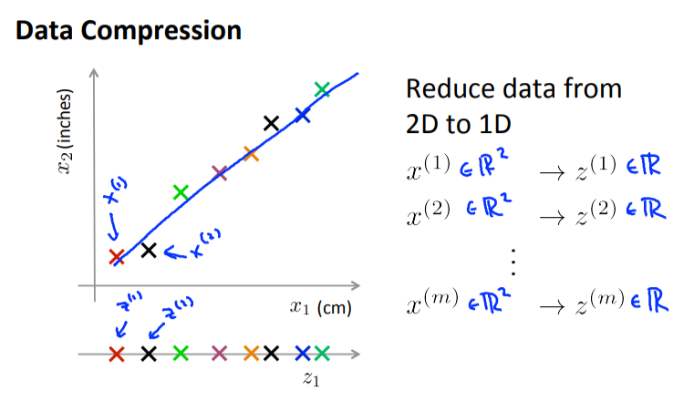

만약 여기 그래프 위의 선에 모든 원본 예시를 투영함으로써 원래 데이터셋의 근사치를 얻을 수 있다면, 단지 한 개의 숫자로 각각의 위치를 표현하는 것

이렇게 하면 메모리 요구 사항이나 공간 요구 사항, 또는 데이터를 저장하는 방법에 대한 요구 사항이 절반으로 줄어든다.

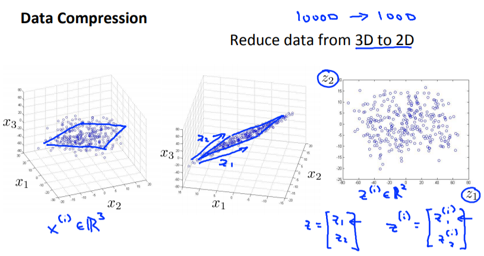

마찬가지로, 3차원 데이터도 2차원으로 표현할 수 있음

## Motivation 2 : Data Visualization

데이터 차원을 줄이는 이유 두번째는 더 잘 이해할 수 있도록 `시각화`하는 것이다.  
많은 ML의 적용에서 시각화는 효과적인 학습 알고리즘 발전에 도움을 준다.

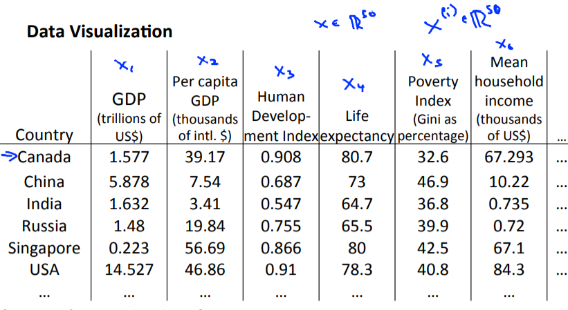

이 데이터를 어떻게 시각화할 것인가?  
feature가 50개라면, 50차원을 그리는 것은 매우 어렵다.

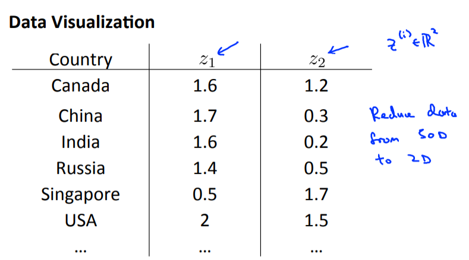

차원 축소를 이용하면, 벡터로 대표되는 각 나라들 대신, z라는 다른 표현을 생각해 낼 수 있다고 하자. 이것은 2차원이다.

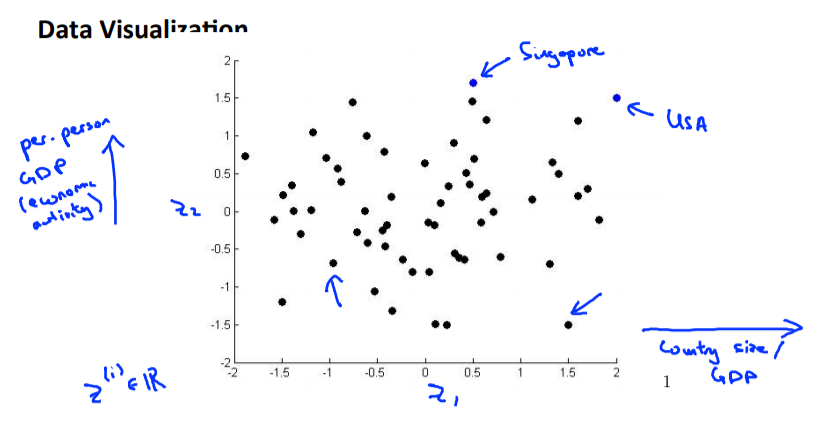

국가들을 2-dimension의 데이터 포인트로 찍고, Z1축은 국가 전체의 GDP라고 보고, Z2축을 인당 GDP라고 할 수 있을 것이다.

전체 데이터를 사용했을 때보다 약간의 설명력이 떨어지지만, 해석의 용이함이 있다.

## Principal Component Analysis problem formulation

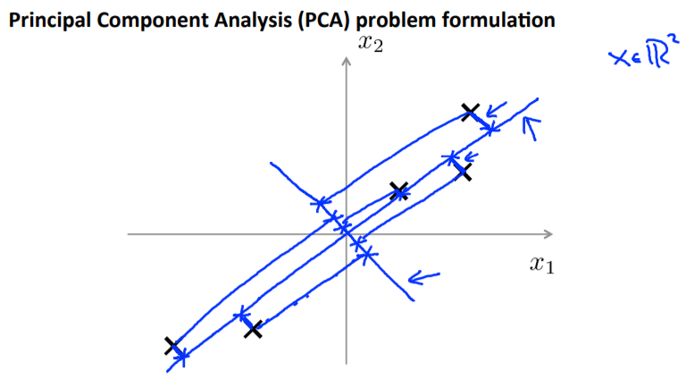

2차원->1차원

데이터를 투영할 선을 찾고 싶은데, 이 선은 데이터를 잘 투영할 것 같은 선이다.(이 선을 잘 찾고도 싶음)

1,3사분면을 지나는 선에 대해 데이터를 투영하면 짧다. 데이터와 선 길이의 제곱합이 최소화되도록하는 데이터를 투영할 수 있는 선이다.(데이터와 선의 길이를 segment(projection error)라고 함)  
비교를 위해 그은 짧은 선은 projection error가 매우 크다. 따라서 PCA에서 2,4사분면을 지나는 선이 아닌 1,3사분면을 지나는 선을 선택하게 된다.

PCA를 적용하기 전에 feature scaling을 적용해야 한다.

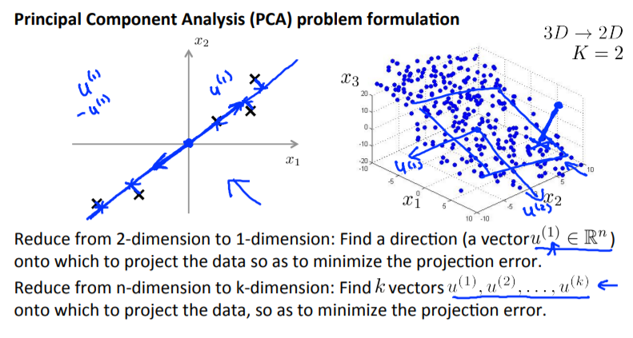

PCA의 목표가 데이터를 2차원->1차원으로 줄이는 것이라고 하면,  
데이터를 투영할 방향인 u1벡터를 찾으면 된다.

부호는 상관없는데 어떤 상수를 곱하면 u1의 반대 방향으로도 갈 수 있다.  
이전의 예처럼 투영할 선을 정의하기 위한 것이다.

3차원을 2차원으로 줄이는 예에서는 u1, u2벡터를 찾게 될 것이다.  
우리가 할 일은 데이터를 u1, u2에 의해 생긴 공간에 투영하는 것

PCA에서는 이런 방식으로 데이터를 투영하게 되어 projection distance를 최소화하는 것이다.

PCA와 linear regression의 차이는 residual과 projection error의 개념을 이해하면 된다.

3D->2D인 예를 보자.  
데이터를 투영할 수 있는 u1와 u2의 두 방향을 찾고 싶다.  
내가 가진 것은 x1, x2, x3라는 세 가지 변수를 가지고 있는데, 이 모든 것이 똑같이 취급된다는 것이다. 이 모든 것들은 대칭적으로 취급되고 내가 예측하려는 특별한 변수 y는 없다.

## Principal Component Analysis algorithm

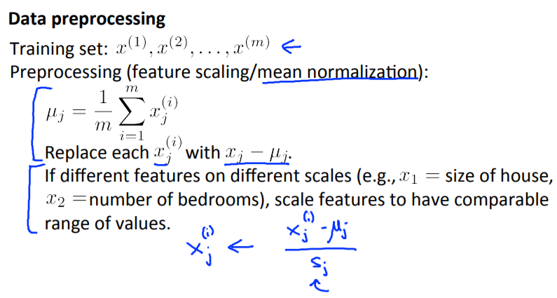

각 관측치에서 평균을 빼면 중심을 0으로 만들 수 있고, 표준편차로 나누어 각 변수별 단위를 없애준다.

이런 전처리를 한 뒤, PCA를 적용한다.

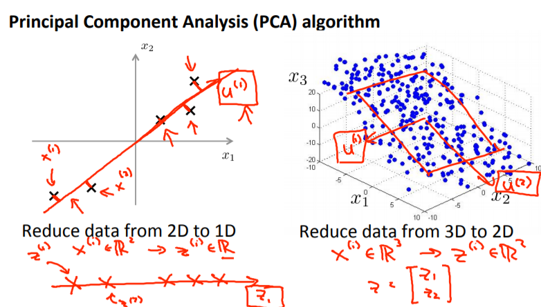

projection error가 최소가 되는 u1, u2를 찾는 것이다.  
1차원에 투영되는 왼편의 그림을 생각한다면, z1은 실수이다. z1은 여기서 첫번째 component를 일컫는다.

3D->2D를 생각해보자.

여기서 PCA가 해야 할 일은 두 가지를 계산하는 방법을 알아야 한다.

1. u1과 u2를 계산
2. Z를 계산

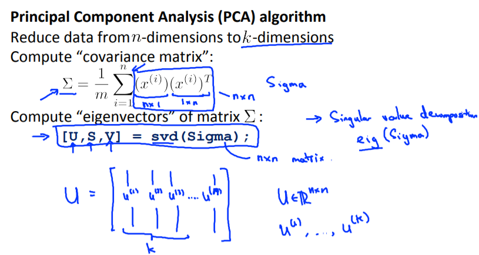

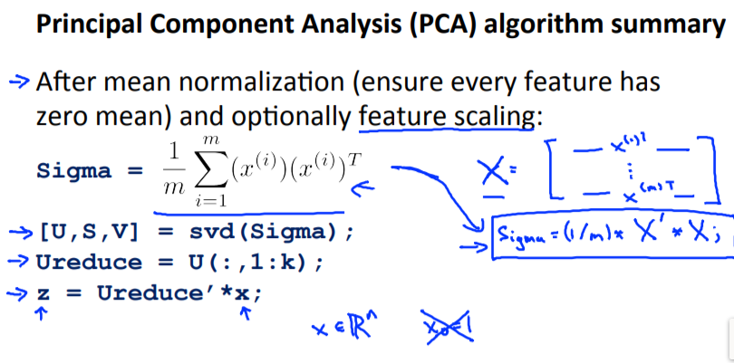

n-dim에서 k-dim으로 축소하는 과정이다.  
먼저 covariance matrix를 계산한뒤 SVD를 시행한다.

- U : orthogonal such as $U^tU=I$, $UU^t\neq I$
- D = diag($d_1$,…,$d_n$) such as $d_1 \ge d_2 \ge...\ge d_p \ge 0$ : singular values of X
- V : orthogonal such as $V^tV=VV^t=I$

$$Z_j = Xv_j = d_ju_j \ :\ j-th\ principal\ component\ of\ X$$
이라고 보통 사용. 여기서는 위의 V가 U이다.

$$z = u_{reduce}^t \times x$$

## Reconstruction from compressed representation

차원이 이 압축된 표현형을 ’압축 해제’해서 압축 전의 고차원 데이터를 근사적으로 얻을 수 있을 것  
예컨대, 100차원의 표현형 zi 가 주어진 상태에서, 원래의 1000차원 값인 xi를 어떻게 되돌려 놓냐는 문제

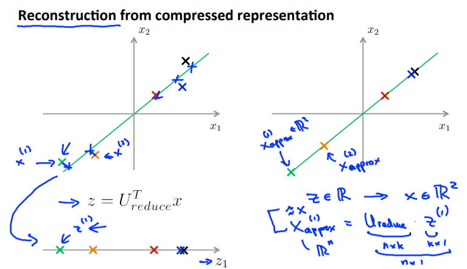

실수 z1 하나만을 사용해서, 1차원 평면에서 각 점들의 위치를 나타낸 것을 어떤 z1이 주어졌을 때, 이를 2차원 공간으로 복원해보자  
다시 말해, 1차원 실수 인 z가 주어졌을 때, 여기에 대응하는 2차원의 근사값 x를 찾아 원래에 가깝게 복원해내는 일이 가능한가?

x에 대해 식을 정리하면 된다.

$$X_{approx} = U_{reduce}Z$$

PCA의 의도는, 투영오차(projection error)의 제곱값이 너무 크지 않도록 해서, x근사값이 z를 유도하는 데 쓰였던 원래 x와 가깝도록 하는 것  
압축-복원과정을 거치면 초록색 선 위에 투영된 점들을 얻게 된다.

원래 데이터의 **‘근사값’**을 얻는데, 이 과정을 **“복원(reconstruction)”**이라고 한다.  
원래의 값 x를 압축된 표현형(representation)으로부터 ’복원’한다는 의미

## Choosing the number of principal commponents

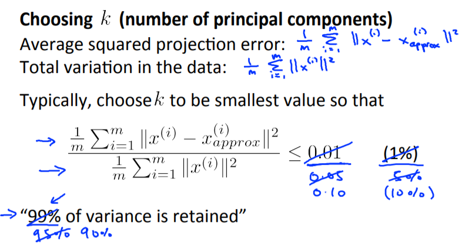

K : the number of principal conponents

어떻게 K를 선택할 것인가?

x와 x의 projection의 거리의 평균 제곱과 전체 변동량의 비율이 0.01이하인 것을 사용한다. 0.05, 0.1등 기준은 어느정도 주관적일 수 있다.

비율이 1%라고 한다면 전체 데이터의 99%의 변동은 축소된 차원에서 유지가 된다고 볼 수 있다.

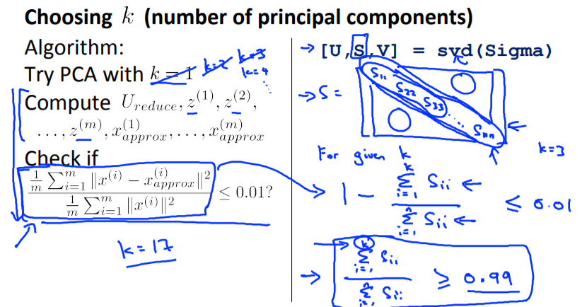

K를 선택하는 방법에는 이전의 방법과 상응하는 방법이 있는데, SVD에서 eigenvalues들을 이용하는 것이다.

1- 축소된 차원과 전체차원의 eigenvalues의 비율은 이전의 식과 같은 방법으로 생각할 수 있다.

마찬가지로, 축소된 차원의 eigenvalues와 전체 eigenvalues의 비율은 데이터의 변동량을 설명하게 된다.

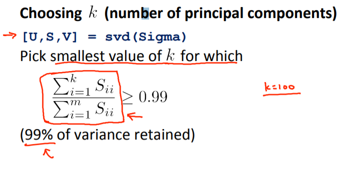

## Advice for applying PCA

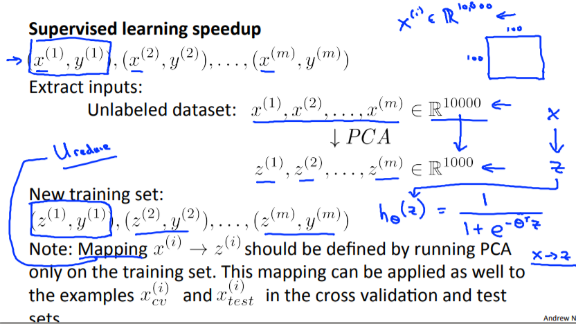

어떤 방식으로 PCA를 적용하게 되는지 알아보자.

PCA를 실행할 때는 cross validation set 또는 test set 데이터가 아닌 데이터의 training set 부분에서만 PCA를 시행해야 한다.

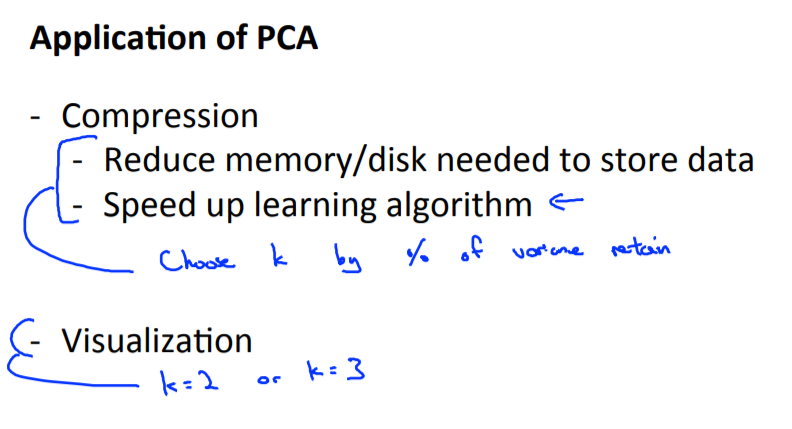

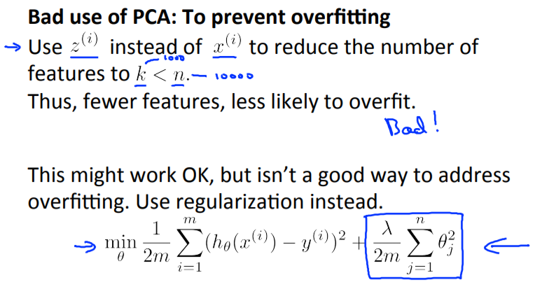

PCA가 overfit을 방지해주는 방법은 아니다.  
overfitting을 방지하기 위해서는 regularization을 대신 사용하는 것이 합당하다.

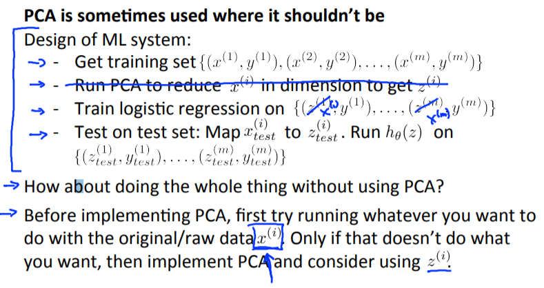

PCA를 사용하기 전에 전체 데이터를 이용하는 것을 고려한 뒤, PCA를 이용해서 하는 것이 좋다.

## PRACTICE

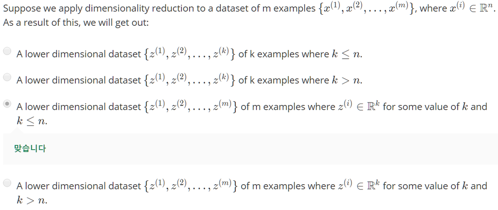

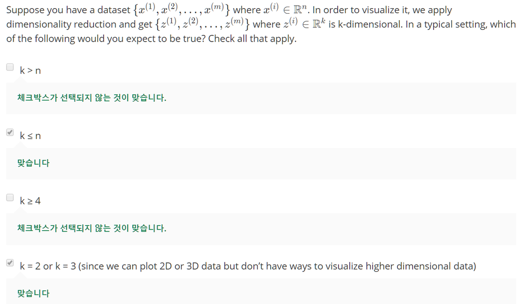

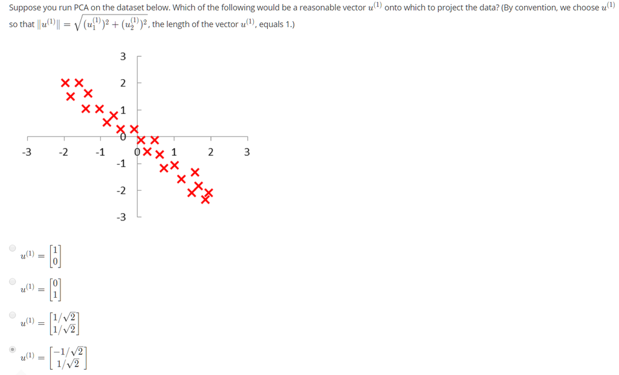

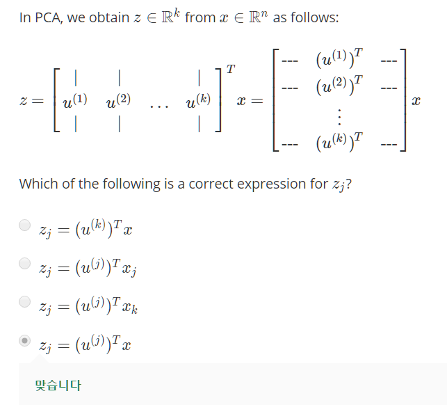

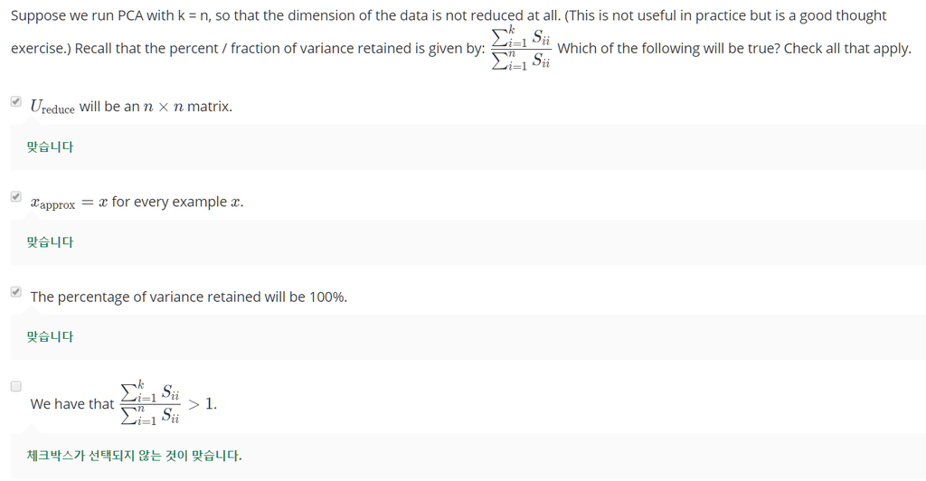

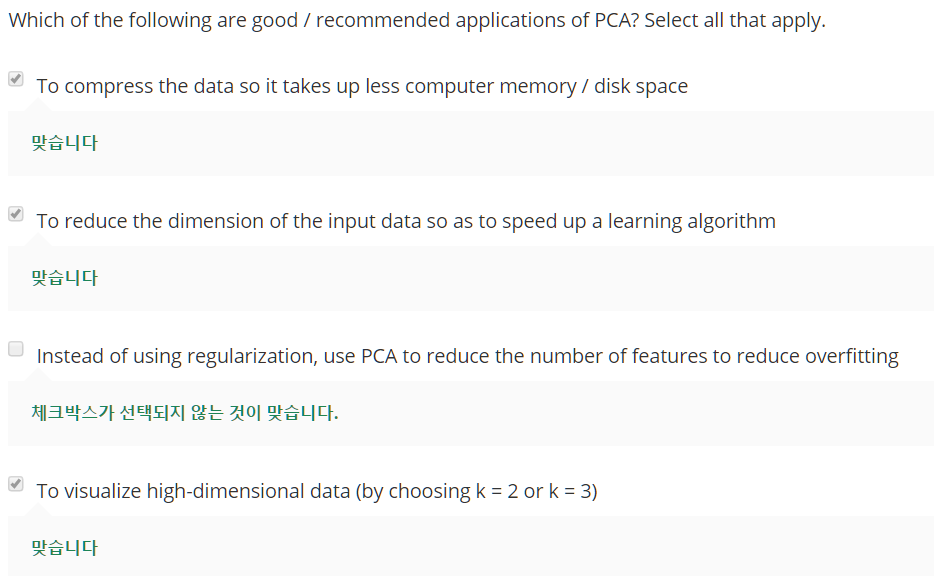